# MA50258: Applied Statistics

Coursework 1

09618

```r
# indicate all your loaded packages here
library(tidyverse)
library(readr)
library(here)

# Other loaded packages
library(lubridate)
library(dplyr)
library(ggplot2)
library(kableExtra)
library(patchwork)
```

```r
formula_tom <- read_csv(here("data", "formula_tom.csv"))
```

## Question 1

The lap time variables (`q1`, `q2`, `q3` and `fastest_lap`) require conversion into a usable format, note the times in the raw data are recorded in minutes and seconds (where seconds are shown to three decimal places). Convert the times to seconds.

```r
# To convert a variable q1 into minutes and seconds format we use ms()
func_convert_time_to_seconds <- function(raw_time) {
  # Check for NA or \N values and return NA for all
  if (is.na(raw_time) || raw_time == "\\N") {
    return(NA)
  }
  else {
    return(as.numeric(ms(raw_time)))
  }
}

q1_in_seconds <- sapply(formula_tom$q1, func_convert_time_to_seconds)
q2_in_seconds <- sapply(formula_tom$q2, func_convert_time_to_seconds)
q3_in_seconds <- sapply(formula_tom$q3, func_convert_time_to_seconds)
fastest_lap_in_seconds <- sapply(formula_tom$fastest_lap, func_convert_time_to_seconds)

# Adding the converted times back to the original data frame
formula_tom$q1_in_seconds <- q1_in_seconds
formula_tom$q2_in_seconds <- q2_in_seconds
formula_tom$q3_in_seconds <- q3_in_seconds
formula_tom$fastest_lap_in_seconds <- fastest_lap_in_seconds
```

## Question 2

Summarise the four lap time variables (`q1`, `q2`, `q3` and `fastest_lap`) giving minimums, means, medians and maximums.

```r
# Function to calculate the required statistics
func_get_summary_stats <- function(x) {
  c(Minimum = min(x, na.rm = TRUE),
    Mean = mean(x, na.rm = TRUE),
    Median = median(x, na.rm = TRUE),
    Maximum = max(x, na.rm = TRUE))
}

# Calculate summaries
summary_q1 <- func_get_summary_stats(q1_in_seconds)
summary_q2 <- func_get_summary_stats(q2_in_seconds)
summary_q3 <- func_get_summary_stats(q3_in_seconds)
summary_fastest_lap <- func_get_summary_stats(fastest_lap_in_seconds)

# Combine into a data frame
summary_df <- data.frame(
  Q1 = summary_q1,
  Q2 = summary_q2,
  Q3 = summary_q3,
  Fastest_Lap = summary_fastest_lap
)

# Use kable for a nice table format
kable(
  summary_df,
      caption = "Summary of Fastest Lap Times of Each Competitor",
      digits = 2,
      align = "c",
      col.names = c(
        "From 1st Qualifying Session",
        "From 2nd Qualifying Session",
        "From 3rd Qualifying Session",
        "Set Over The Race")
      ) %>%
  kable_styling("striped", full_width = F, position = "c")
```

Summary of Fastest Lap Times of Each Competitor

|  | From 1st Qualifying Session | From 2nd Qualifying Session | From 3rd Qualifying Session | Set Over The Race |
| --- | --- | --- | --- | --- |
| Minimum | 53.90 | 53.65 | 53.38 | 55.40 |
| Mean | 88.75 | 88.09 | 87.76 | 90.99 |
| Median | 87.19 | 87.40 | 87.29 | 90.50 |
| Maximum | 1002.64 | 132.47 | 129.78 | 202.30 |

What conclusions can you draw from your summaries?

Answer

The summary statistics for the four lap time variables are presented in the table above. The minimum, mean, median and maximum times are calculated for each of the four variables.

## Question 3

Produce a scatter plot of `q1` against `q3`. In the same plot, add an overlay of the fit of the corresponding LOESS fit as well as the fit of the following linear regression model:

$$E[\verb|q3||\verb|q1|]=\alpha_0 +
\alpha_1 \,\verb|q1|$$

[figure not shown]

```r
# EDA Code
ggplot(
  formula_tom,
  aes(x = q1_in_seconds, y = q3_in_seconds)) +
  geom_point(alpha = 0.25) +
  geom_smooth(aes(col = "LOESS Smoothing"), method = "loess", se = F, linewidth = 0.5) +
  geom_smooth(aes(col = "Linear Model Fit"), method = "lm", se = F, linewidth = 0.5) +
  labs(
    title = "Scatterplot of q1 against q3",
    x = "q1 (seconds)",
    y = "q3 (seconds)",
    subtitle = "Excluding an extreme outlier"
  ) +
  theme(legend.position = "bottom") +
  scale_color_manual(
    name = "Fits",
    values = c("LOESS Smoothing" = "red", "Linear Model Fit" = "blue")
  )
```

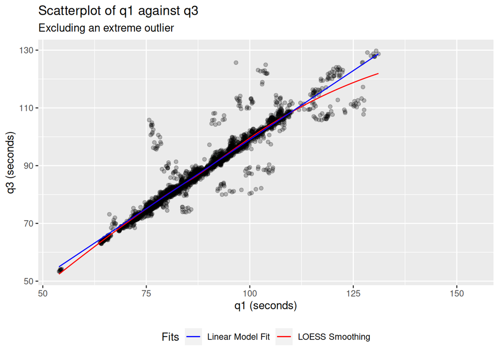

```r
# EDA Code
# Filtering out an extreme outlier (datum no. 2568 that has a lap time of 16min), this is done by setting a threshold of 180 seconds filter
formula_tom_q1_outlier_filtered <- formula_tom %>% filter(q1_in_seconds < 180)
ggplot(
  formula_tom_q1_outlier_filtered,
  aes(x = q1_in_seconds, y = q3_in_seconds)) +
  geom_point(alpha = 0.25) +
  geom_smooth(aes(col = "LOESS Smoothing"), method = "loess", se = F, linewidth = 0.5) +
  geom_smooth(aes(col = "Linear Model Fit"), method = "lm", se = F, linewidth = 0.5) +
  labs(
    title = "Scatterplot of q1 against q3",
    x = "q1 (seconds)",
    y = "q3 (seconds)",
    subtitle = "Excluding an extreme outlier"
  ) +
  theme(legend.position = "bottom") +
  scale_color_manual(
    name = "Fits",
    values = c("LOESS Smoothing" = "red", "Linear Model Fit" = "blue")
  )
```

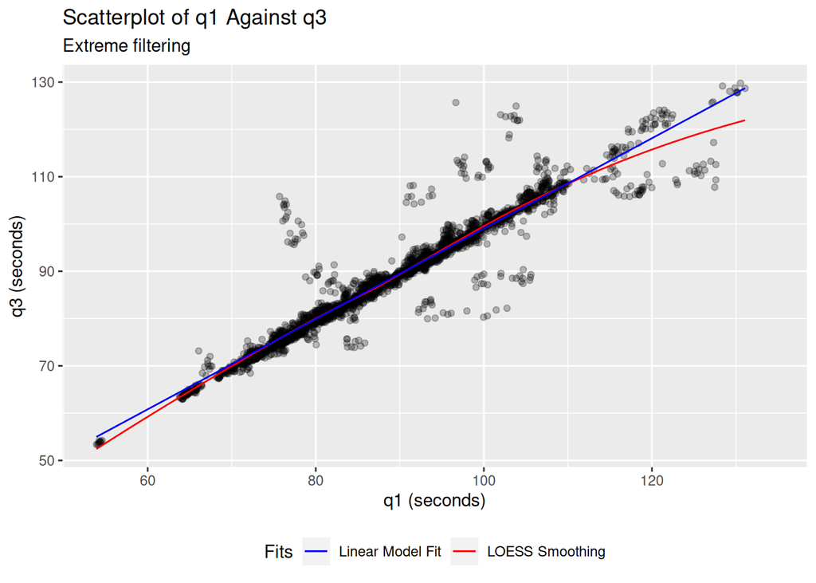

```r
# EDA Code
formula_tom_q1_extreme_filtering  <- formula_tom %>% filter(q1_in_seconds < 135)
ggplot(
  formula_tom_q1_extreme_filtering,
  aes(x = q1_in_seconds, y = q3_in_seconds)) +
  geom_point(alpha = 0.25) +
  geom_smooth(aes(col = "LOESS Smoothing"), method = "loess", se = F, linewidth = 0.5) +
  geom_smooth(aes(col = "Linear Model Fit"), method = "lm", se = F, linewidth = 0.5) +
  labs(
    title = "Scatterplot of q1 Against q3",
    x = "q1 (seconds)",
    y = "q3 (seconds)",
    subtitle = "Extreme filtering"
  ) +
  theme(legend.position = "bottom") +
  scale_color_manual(
    name = "Fits",
    values = c("LOESS Smoothing" = "red", "Linear Model Fit" = "blue")
  )
```

```r
# EDA Code
unfitted_data_points <- formula_tom %>% filter(q1_in_seconds > 135) %>% select(q1_in_seconds, q3_in_seconds)
kable(
  unfitted_data_points,
  caption = "Checking Unfitted Data Points",
  digits = 2,
  align = "c",
) %>%
  kable_styling("striped", full_width = F, position = "c")
```

Checking Unfitted Data Points

| q1_in_seconds | q3_in_seconds |
| --- | --- |
| 1002.64 | NA |
| 141.16 | NA |
| 141.49 | NA |
| 141.68 | NA |
| 142.07 | NA |
| 142.20 | NA |
| 142.22 | NA |
| 142.36 | NA |
| 142.44 | NA |
| 142.63 | NA |
| 143.33 | NA |
| 143.90 | NA |
| 144.05 | NA |
| 144.12 | NA |
| 145.11 | NA |
| 145.70 | NA |
| 146.04 | NA |
| 146.08 | NA |
| 146.74 | NA |
| 146.90 | NA |
| 147.16 | NA |
| 147.21 | NA |
| 148.16 | NA |
| 148.98 | NA |
| 150.93 | NA |
| 151.76 | NA |
| 153.88 | NA |
| 138.75 | NA |
| 141.61 | NA |

What can you say about each fit, is there any agreement between them?